# University Clustering

### Wrap-Up

So there you have it. Even though individual schools can have similar values for various selectivity measures, k-means helps us tell whether a school really is similar to another, not just based on one or two metrics, but the sum total of all the metrics that we deem important.

A good extension of this analysis could be to use the results of these groupings in a predictive model, allowing you to build different models for each cluster of schools. This is potentially useful since each resulting model’s coefficients need only to describe a certain subset of the data as opposed to all the data, which could ultimately result in a more accurate model.

And what about those schools I brought up in the beginning, College of Wooster and Dayton? Turns out they do belong to different groups in our analysis, with Dayton in the ‘Small Privates’ group and Wooster in the ‘Elites’ group.

```r
library(ggrepel)
```

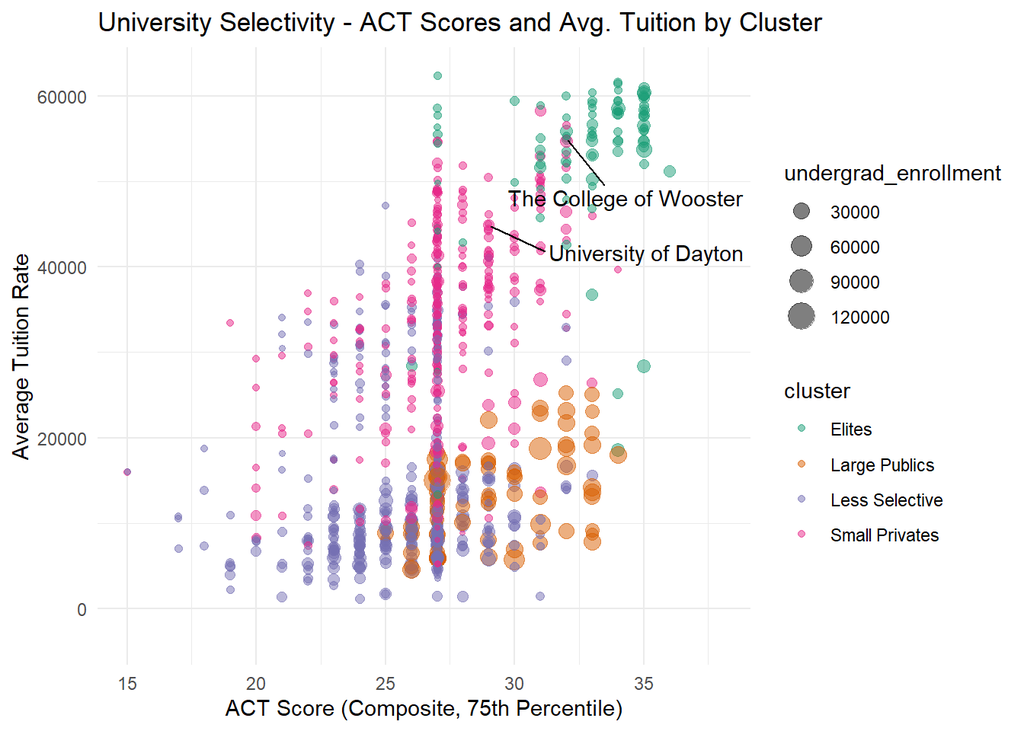

```r
school_data %>%
  rename(undergrad_enrollment = ug_enroll) %>%
  ggplot(aes(x = act_score, y = avg_tuition)) +
  geom_point(aes(color = cluster, size = undergrad_enrollment), alpha = 0.5) +
  geom_text_repel(aes(label=ifelse(school == 'The College of Wooster' | school == 'University of Dayton', school, '')), nudge_x = 2, nudge_y = -4500, max.overlaps = 2000) +
  scale_color_brewer(palette = 'Dark2') +
  theme_minimal() +
  labs(x = 'ACT Score (Composite, 75th Percentile)',
       y = 'Average Tuition Rate',
       title = 'University Selectivity - ACT Scores and Avg. Tuition by Cluster')
```